# MATH5741M: Statistical Theory and Methods

Benjamin Thorpe

2022-09-06

# Formulae

## Summary statistics

- Sample mean:
  $$\displaystyle \quad \overline{x} = \frac{1}{n} \sum_{i=1}^{n}x_i$$
- Sample variance (unbiased estimator of population variance):
  $$s^2 = {1 \over n-1}\sum_{i=1}^{n}(x_i-\overline{x})^2$$
- Sample correlation:
  $$\displaystyle \quad r_{xy}=\frac{\sum_{i = 1}^{n} (x_i-\overline{x})(y_i-\overline{y})}{(n-1)s_x s_y}$$

## Expectations

- Expectation of a random variable:
  $${\mathsf E}(X) = \sum_{x\in J}xf(x) \qquad \text{(discrete case)}$$
  $${\mathsf E}(X) = \int_{-\infty }^{\infty }xf(x)dx \qquad \text{(continuous case)}$$
- Expectation of a function of a random variable:
  $${\mathsf E}\left[ h(X) \right] = \sum_{x\in J} h(x)f(x) \qquad \text{(discrete case)}$$
  $${\mathsf E}\left[ h(X) \right] =\int_{-\infty}^{\infty} h(x)\, f(x)\, dx \qquad \text{ (continuous case)}$$

## Distributions

- Binomial distribution:
  $${\mathsf P}(X = x) = {n\choose x} p^x(1-p)^{n-x}\qquad \mbox{where}\quad {n\choose x}
  ={n!\over x!(n-x)!}$$
  Mean $= np\quad$ Variance $= np(1-p)$
- Poisson distribution:
  $${\mathsf P}(X=x) = {\lambda^x e^{-\lambda}\over x!}\qquad (x=0,1,2,\ldots)$$
  Mean $= \lambda\quad$ Variance $=\lambda$
- Geometric distribution:
  $${\mathsf P}(X=x) = (1-p)^{x}p \qquad (r=0,1,2,\ldots)$$
  Mean $= (1-p)/p\quad$ Variance $= (1-p)/p^2$
- Uniform (rectangular) distribution:
  $$f(x) = {1\over b-a}\qquad (a \le x \le b)$$
  Mean $= (a+b)/2\quad$ Variance $=(b-a)^2 /12$
- Exponential distribution:
  $$f(x) = \lambda e^{-\lambda x}\qquad (x \ge 0)$$
  Mean $= 1/\lambda\quad$ Variance $= 1/\lambda^2$
- Beta distribution:
  $$f(x) \propto x^{\alpha-1}(1 - x)^{\beta-1} \qquad (x \in [0,1])$$
  Mean $= \alpha/(\alpha + \beta)\quad$ Variance $= \alpha\beta/(\alpha + \beta)^2(\alpha+\beta+1)$
- Standard normal distribution, $N(0,1)$:
  $$\begin{eqnarray*}
  f(z) &=& {1 \over\sqrt{2\pi}}e^{-{1\over 2}z^2}\\
  \Phi(z) & = & {\mathsf P}(Z\le z) = \int_{-\infty}^z f(u)du
  \end{eqnarray*}$$

## Hypothesis testing

- Confidence limits for the mean:
  $$\displaystyle \quad \bar x \pm z_{\alpha/2}{\sigma\over\sqrt{n}}\quad \text{or}\quad \bar x\pm t_{n-1}(\alpha/2){s\over\sqrt{n}}$$
- Test statistics for the mean:
  $$\displaystyle \quad z={\bar x -\mu_o\over \sigma/\sqrt{n}}\quad\text{or}\quad
  t={\bar x -\mu_o\over s/\sqrt{n}}$$

# Statistical tables

## Normal distribution tables

The first table gives
$$\Phi(x)=\frac{1}{\sqrt{2\pi}}\int_{-\infty}^x \exp\left({-\frac{1}{2}z^2}\right)dz$$
and this corresponds to the shaded area in the figure to the right. $\Phi(x)$ is the probability that a random variable, normally distributed with mean $0$ and variance $1$, will be less than or equal to $x$. When $x<0$ use
$$\Phi(x) = 1-\Phi(-x)$$
as the normal distribution with mean zero is symmetric about zero. To interpolate, use the formula
$$\Phi(x)\approx\Phi(x_1)+\frac{x-x_1}{x_2-x_1}\,\bigl(\Phi(x_2)-\Phi(x_1)\bigr)$$

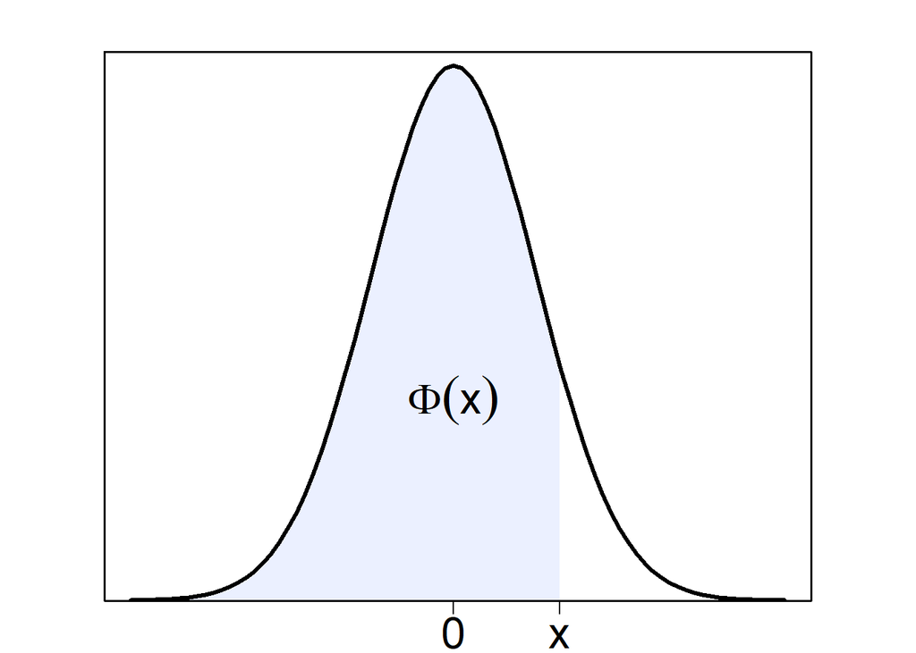

Figure 1: Plot of the standard normal density curve. The cumulative distribution function $\Phi(x)$ is shown as the shaded area under the curve.

**Table 1**

| $x$ | $\Phi(x)$ | $x$ | $\Phi(x)$ | $x$ | $\Phi(x)$ | $x$ | $\Phi(x)$ | $x$ | $\Phi(x)$ | $x$ | $\Phi(x)$ |
| --- | --- | --- | --- | --- | --- | --- | --- | --- | --- | --- | --- |
| $\textbf{0.00}$ | 0.5000 | $\textbf{0.50}$ | 0.6915 | $\textbf{1.00}$ | 0.8413 | $\textbf{1.50}$ | 0.9332 | $\textbf{2.00}$ | 0.9772 | $\textbf{2.50}$ | 0.9938 |
| $\textbf{0.05}$ | 0.5199 | $\textbf{0.55}$ | 0.7088 | $\textbf{1.05}$ | 0.8531 | $\textbf{1.55}$ | 0.9394 | $\textbf{2.05}$ | 0.9798 | $\textbf{2.55}$ | 0.9946 |
| $\textbf{0.10}$ | 0.5398 | $\textbf{0.60}$ | 0.7257 | $\textbf{1.10}$ | 0.8643 | $\textbf{1.60}$ | 0.9452 | $\textbf{2.10}$ | 0.9821 | $\textbf{2.60}$ | 0.9953 |
| $\textbf{0.15}$ | 0.5596 | $\textbf{0.65}$ | 0.7422 | $\textbf{1.15}$ | 0.8749 | $\textbf{1.65}$ | 0.9505 | $\textbf{2.15}$ | 0.9842 | $\textbf{2.65}$ | 0.9960 |
| $\textbf{0.20}$ | 0.5793 | $\textbf{0.70}$ | 0.7580 | $\textbf{1.20}$ | 0.8849 | $\textbf{1.70}$ | 0.9554 | $\textbf{2.20}$ | 0.9861 | $\textbf{2.70}$ | 0.9965 |
| $\textbf{0.25}$ | 0.5987 | $\textbf{0.75}$ | 0.7734 | $\textbf{1.25}$ | 0.8944 | $\textbf{1.75}$ | 0.9599 | $\textbf{2.25}$ | 0.9878 | $\textbf{2.75}$ | 0.9970 |
| $\textbf{0.30}$ | 0.6179 | $\textbf{0.80}$ | 0.7881 | $\textbf{1.30}$ | 0.9032 | $\textbf{1.80}$ | 0.9641 | $\textbf{2.30}$ | 0.9893 | $\textbf{2.80}$ | 0.9974 |
| $\textbf{0.35}$ | 0.6368 | $\textbf{0.85}$ | 0.8023 | $\textbf{1.35}$ | 0.9115 | $\textbf{1.85}$ | 0.9678 | $\textbf{2.35}$ | 0.9906 | $\textbf{2.85}$ | 0.9978 |
| $\textbf{0.40}$ | 0.6554 | $\textbf{0.90}$ | 0.8159 | $\textbf{1.40}$ | 0.9192 | $\textbf{1.90}$ | 0.9713 | $\textbf{2.40}$ | 0.9918 | $\textbf{2.90}$ | 0.9981 |
| $\textbf{0.45}$ | 0.6736 | $\textbf{0.95}$ | 0.8289 | $\textbf{1.45}$ | 0.9265 | $\textbf{1.95}$ | 0.9744 | $\textbf{2.45}$ | 0.9929 | $\textbf{2.95}$ | 0.9984 |

The inverse function $\Phi^{-1}(p)$ is tabulated below for various values of $p$.

**Table 2**

| $p$ | $\textbf{0.900}$ | $\textbf{0.950}$ | $\textbf{0.975}$ | $\textbf{0.990}$ | $\textbf{0.995}$ |
| --- | --- | --- | --- | --- | --- |
| $\Phi^{-1}(p)$ | 1.282 | 1.645 | 1.960 | 2.326 | 2.576 |

## Percentage points of the t-distribution

This table gives the percentage points $t_{\nu}(P)$ for various values of $P$ and degrees of freedom $\nu$, as indicated by the figure to the right.

The lower percentage points are given by symmetry as $-t_{\nu}(P)$, and the probability that $|t| \ge t_{\nu}(P)$ is $2P/100$.

The limiting distribution as $\nu\rightarrow\infty$ is the normal distribution with mean $0$ and variance $1$.

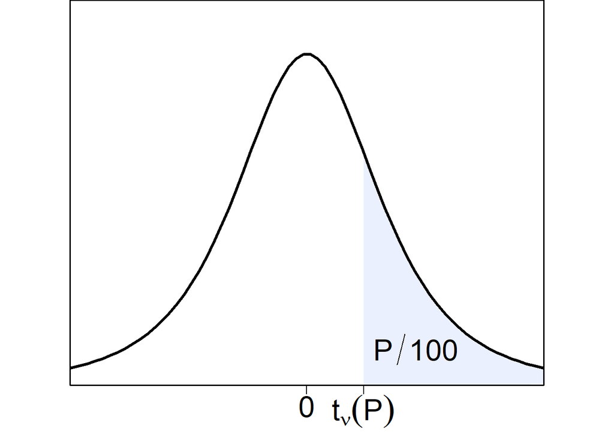

Figure 2: Plot of the t distribution density curve.

|  | $P = 10$ | $P = 5$ | $P = 2.5$ | $P = 1$ | $P = 0.5$ | $P = 0.1$ | $P = 0.05$ |
| --- | --- | --- | --- | --- | --- | --- | --- |
| $\nu = 1$ | 3.078 | 6.314 | 12.706 | 31.821 | 63.657 | 318.309 | 636.619 |
| $\nu = 2$ | 1.886 | 2.920 | 4.303 | 6.965 | 9.925 | 22.327 | 31.599 |
| $\nu = 3$ | 1.638 | 2.353 | 3.182 | 4.541 | 5.841 | 10.215 | 12.924 |
| $\nu = 4$ | 1.533 | 2.132 | 2.776 | 3.747 | 4.604 | 7.173 | 8.610 |
| $\nu = 5$ | 1.476 | 2.015 | 2.571 | 3.365 | 4.032 | 5.893 | 6.869 |
| $\nu = 6$ | 1.440 | 1.943 | 2.447 | 3.143 | 3.707 | 5.208 | 5.959 |
| $\nu = 7$ | 1.415 | 1.895 | 2.365 | 2.998 | 3.499 | 4.785 | 5.408 |
| $\nu = 8$ | 1.397 | 1.860 | 2.306 | 2.896 | 3.355 | 4.501 | 5.041 |
| $\nu = 9$ | 1.383 | 1.833 | 2.262 | 2.821 | 3.250 | 4.297 | 4.781 |
| $\nu = 10$ | 1.372 | 1.812 | 2.228 | 2.764 | 3.169 | 4.144 | 4.587 |
| $\nu = 11$ | 1.363 | 1.796 | 2.201 | 2.718 | 3.106 | 4.025 | 4.437 |
| $\nu = 12$ | 1.356 | 1.782 | 2.179 | 2.681 | 3.055 | 3.930 | 4.318 |
| $\nu = 13$ | 1.350 | 1.771 | 2.160 | 2.650 | 3.012 | 3.852 | 4.221 |
| $\nu = 14$ | 1.345 | 1.761 | 2.145 | 2.624 | 2.977 | 3.787 | 4.140 |
| $\nu = 15$ | 1.341 | 1.753 | 2.131 | 2.602 | 2.947 | 3.733 | 4.073 |
| $\nu = 16$ | 1.337 | 1.746 | 2.120 | 2.583 | 2.921 | 3.686 | 4.015 |
| $\nu = 18$ | 1.330 | 1.734 | 2.101 | 2.552 | 2.878 | 3.610 | 3.922 |
| $\nu = 21$ | 1.323 | 1.721 | 2.080 | 2.518 | 2.831 | 3.527 | 3.819 |
| $\nu = 25$ | 1.316 | 1.708 | 2.060 | 2.485 | 2.787 | 3.450 | 3.725 |
| $\nu = 30$ | 1.310 | 1.697 | 2.042 | 2.457 | 2.750 | 3.385 | 3.646 |
| $\nu = 40$ | 1.303 | 1.684 | 2.021 | 2.423 | 2.704 | 3.307 | 3.551 |
| $\nu = 50$ | 1.299 | 1.676 | 2.009 | 2.403 | 2.678 | 3.261 | 3.496 |
| $\nu = 70$ | 1.294 | 1.667 | 1.994 | 2.381 | 2.648 | 3.211 | 3.435 |
| $\nu = 100$ | 1.290 | 1.660 | 1.984 | 2.364 | 2.626 | 3.174 | 3.390 |
| $\nu = \infty$ | 1.282 | 1.645 | 1.960 | 2.326 | 2.576 | 3.090 | 3.291 |

## Percentage points of the $\chi^2$-distribution

This table gives percentage points $\chi^2_{\nu}(P)$ for various values of $P$ and degrees of freedom $\nu$, as indicated by the figure to the right.

If $X$ is a variable distributed as $\chi^2$ with $\nu$ degrees of freedom, $P/100$ is the probability that $X\ge \chi^2_{\nu}(P)$.

For $\nu> 100$, $\sqrt{2X}$ is approximately normally distributed with mean $\sqrt{2\nu -1}$ and variance $1$.

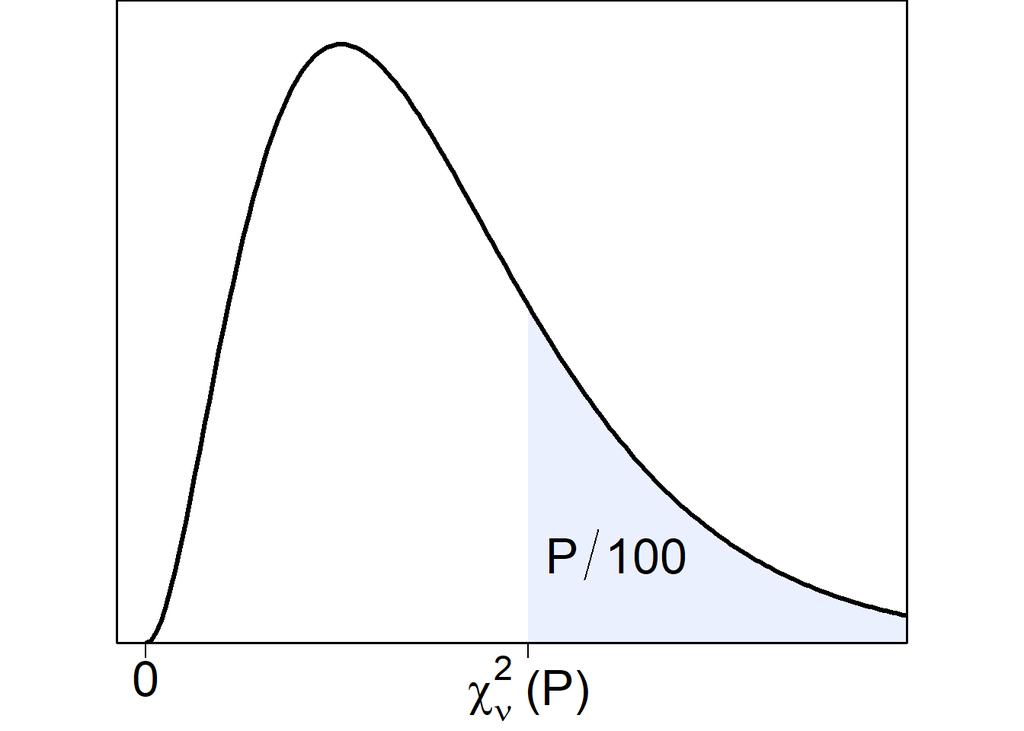

Figure 3: Plot of the $\chi^2$ distribution density curve.

|  | $P = 10$ | $P = 5$ | $P = 2.5$ | $P = 1$ | $P = 0.5$ | $P = 0.1$ | $P = 0.05$ |
| --- | --- | --- | --- | --- | --- | --- | --- |
| $\nu = 1$ | 2.706 | 3.841 | 5.024 | 6.635 | 7.879 | 10.828 | 12.116 |
| $\nu = 2$ | 4.605 | 5.991 | 7.378 | 9.210 | 10.597 | 13.816 | 15.202 |
| $\nu = 3$ | 6.251 | 7.815 | 9.348 | 11.345 | 12.838 | 16.266 | 17.730 |
| $\nu = 4$ | 7.779 | 9.488 | 11.143 | 13.277 | 14.860 | 18.467 | 19.997 |
| $\nu = 5$ | 9.236 | 11.070 | 12.833 | 15.086 | 16.750 | 20.515 | 22.105 |
| $\nu = 6$ | 10.645 | 12.592 | 14.449 | 16.812 | 18.548 | 22.458 | 24.103 |
| $\nu = 7$ | 12.017 | 14.067 | 16.013 | 18.475 | 20.278 | 24.322 | 26.018 |
| $\nu = 8$ | 13.362 | 15.507 | 17.535 | 20.090 | 21.955 | 26.124 | 27.868 |
| $\nu = 9$ | 14.684 | 16.919 | 19.023 | 21.666 | 23.589 | 27.877 | 29.666 |
| $\nu = 10$ | 15.987 | 18.307 | 20.483 | 23.209 | 25.188 | 29.588 | 31.420 |
| $\nu = 11$ | 17.275 | 19.675 | 21.920 | 24.725 | 26.757 | 31.264 | 33.137 |
| $\nu = 12$ | 18.549 | 21.026 | 23.337 | 26.217 | 28.300 | 32.909 | 34.821 |
| $\nu = 13$ | 19.812 | 22.362 | 24.736 | 27.688 | 29.819 | 34.528 | 36.478 |
| $\nu = 14$ | 21.064 | 23.685 | 26.119 | 29.141 | 31.319 | 36.123 | 38.109 |
| $\nu = 15$ | 22.307 | 24.996 | 27.488 | 30.578 | 32.801 | 37.697 | 39.719 |
| $\nu = 16$ | 23.542 | 26.296 | 28.845 | 32.000 | 34.267 | 39.252 | 41.308 |
| $\nu = 17$ | 24.769 | 27.587 | 30.191 | 33.409 | 35.718 | 40.790 | 42.879 |
| $\nu = 18$ | 25.989 | 28.869 | 31.526 | 34.805 | 37.156 | 42.312 | 44.434 |
| $\nu = 19$ | 27.204 | 30.144 | 32.852 | 36.191 | 38.582 | 43.820 | 45.973 |
| $\nu = 20$ | 28.412 | 31.410 | 34.170 | 37.566 | 39.997 | 45.315 | 47.498 |
| $\nu = 25$ | 34.382 | 37.652 | 40.646 | 44.314 | 46.928 | 52.620 | 54.947 |
| $\nu = 30$ | 40.256 | 43.773 | 46.979 | 50.892 | 53.672 | 59.703 | 62.162 |
| $\nu = 40$ | 51.805 | 55.758 | 59.342 | 63.691 | 66.766 | 73.402 | 76.095 |
| $\nu = 50$ | 63.167 | 67.505 | 71.420 | 76.154 | 79.490 | 86.661 | 89.561 |
| $\nu = 80$ | 96.578 | 101.879 | 106.629 | 112.329 | 116.321 | 124.839 | 128.261 |